# 단순 회귀모형 실습

이현정

2021 3 31

### 단순 회귀분석 예제

```r
data(cars)
head(cars)
```

```
##   speed dist
## 1     4    2
## 2     4   10
## 3     7    4
## 4     7   22
## 5     8   16
## 6     9   10
```

독립변수는 speed이고, 종속 변수는 dist라고 본다.

식은 dist(Y)=X0+X1*(speed)+e

이 데이터를 회귀분석한다.

```r
m1<-lm(dist~speed,cars)
summary(m1)
```

```
##
## Call:
## lm(formula = dist ~ speed, data = cars)
##
## Residuals:
##     Min      1Q  Median      3Q     Max
## -29.069  -9.525  -2.272   9.215  43.201
##
## Coefficients:
##             Estimate Std. Error t value Pr(>|t|)
## (Intercept) -17.5791     6.7584  -2.601   0.0123 *
## speed         3.9324     0.4155   9.464 1.49e-12 ***
## ---
## Signif. codes:  0 '***' 0.001 '**' 0.01 '*' 0.05 '.' 0.1 ' ' 1
##
## Residual standard error: 15.38 on 48 degrees of freedom
## Multiple R-squared:  0.6511, Adjusted R-squared:  0.6438
## F-statistic: 89.57 on 1 and 48 DF,  p-value: 1.49e-12
```

*여기서 Intercept는 y절편을 의미한다. x0 = -17.579*

*speed는 회귀선의 기울기를 의미한다. x1 = 3.932*

그래서 식은 dist(Y)=-17.579 + (3.932)*(speed)+e 로 구해질 수 있다. 유의수준 5%하에서 F-통계량의 p-값이 0.05보다 작기때문에 추정된 회귀식은 통계적으로 유의하다고 볼 수 있다.

이렇게 추정한 회귀모형을 그래프로 소개하고자 한다.

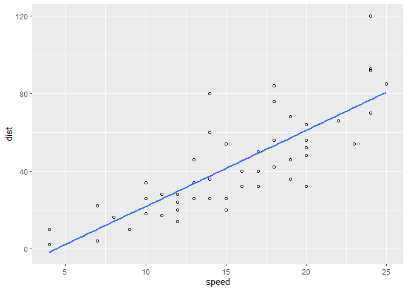

```r
library(ggplot2)
ggplot(m1,aes(x=speed,y=dist))+
  geom_point(shape=1)+#중앙이 빈 동그라미 만들기 shape=1
  stat_smooth(method='lm',se=F) #단순선형회귀분석옵션method='lm',se=F 표준오차를 표현하지않는다는 것.
```

이 회귀선이 타당한지 보기위해 회귀식과 모형간의 잔차를 따로 구할 수 있다.

그리고, 이 잔차가 정규 분포를 따르는지 확인한다.

```r
res_m1<-residuals(m1)
shapiro.test(res_m1)
```

```
##
##  Shapiro-Wilk normality test
##
## data:  res_m1
## W = 0.94509, p-value = 0.02152
```

*귀무가설: 정규분포를 따른다.*

*대립가설: 정규분포를 따르지않는다.*

여기서 p-value가 0.02152 기 때문에, 귀무가설을 기각할 수 있고 따라서 이 회귀선의 잔차는 정규분포를 따르지않는다.

정말로 정규분포를 따르지않는것일까? 이 모형은 회귀분석이 불가한가?

# **이 모형은 회귀가정들을 만족할까?**

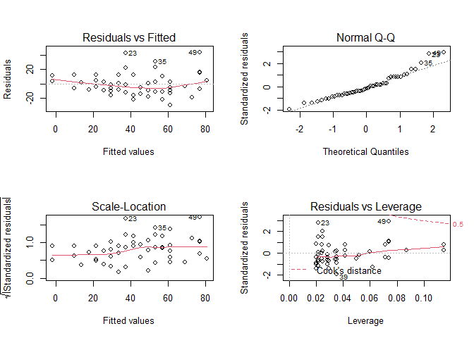

```r
par(mfrow=c(2,2))
plot(m1)
```

왼쪽 위의 그림을 보면 그래프의 기울기가 거의 0에 가까우므로 *선형성 가정*을 만족한다.

왼쪽 아래의 그림을 보면 그래프의 기울기가 거의 0에 가까우므로 *등분산성 가정*을 만족한다.

오른쪽 밑의 그림에서는 23번과 49번의 이상치가 확인된다.

독립성 가정을 만족하는지 확인하기 위해 durbinWatson 검정을 시행한다.

```r
#install.packages("durbinWatsonTest")
library(car)
durbinWatsonTest(m1)
```

```
##  lag Autocorrelation D-W Statistic p-value
##    1       0.1604322      1.676225    0.15
##  Alternative hypothesis: rho != 0
```

*귀무가설: 잔차들 사이에 자기상관관계가 없다.* *대립가설: 잔차가 자기상관관계가 있다.*

여기서 p-value가 매우 크므로, 귀무가설을 채택하여 잔차들 사이에 상관관계가 없다는 뜻이다. 그러므로 독립성을 만족한다.